# Impact of Race on Baseline Asthma Severity and Response to Biologic Therapy in the First 12 Months Post Biologic Initiation

# 1 Study Overview

## 1.1 Background

The purpose of the study is to identify racial and socioeconomic factors that may impact outcomes in patients with moderate to severe asthma. The first phase of the study will describe the moderate to severe asthma patient population at VUMC prescribed biologic asthma therapies and identify differences in rates of healthcare utilization, asthma exacerbations (as determined by refill frequency of short-acting beta agonist (SABA) inhalers, systemic corticosteroids prescribed, hospitalizations/urgent care visits), clinical response to treatment (as defined as change in FEV1 in mL from baseline, SABA inhaler and systemic corticosteroid frequency), adherence and persistence to specialty medications, and clinic engagement by racial and socio-economic status within the healthcare system.

## 1.2 Methods

Retrospective cohort review of patients prescribed benralizumab, dupilumab, mepolizumab and omalizumab from 01/01/2019-6/30/2022.

## 1.3 Outcomes

Primary Outcome: Determine if there is an association between race, ethnicity, or socioeconomic status (SES) and baseline disease status at the time of biologic initiation.

# 2 Patient Demographics and Characteristics

## 2.1 Main Summary

| **Characteristic** | **N** | **Overall**, N = 215<sup>1</sup> | **Black or African American**, N = 59<sup>1</sup> | **Other/Unknown**, N = 8<sup>1</sup> | **White**, N = 148<sup>1</sup> |
| --- | --- | --- | --- | --- | --- |
| Age at referral | 215 |  |  |  |  |
| Mean (SD) |  | 44 (21) | 34 (20) | 39 (21) | 48 (20) |
| Median (IQR) |  | 48 (26, 60) | 33 (16, 52) | 41 (21, 47) | 53 (37, 62) |
| Range |  | 6, 84 | 7, 79 | 15, 80 | 6, 84 |
| Age Category | 215 |  |  |  |  |
| Adolescent (<= 18) |  | 44 (20.5%) | 22 (37.3%) | 2 (25.0%) | 20 (13.5%) |
| Adult (19-64) |  | 133 (61.9%) | 35 (59.3%) | 5 (62.5%) | 93 (62.8%) |
| Elder adult (65+) |  | 38 (17.7%) | 2 (3.39%) | 1 (12.5%) | 35 (23.6%) |
| Gender | 215 |  |  |  |  |
| Female |  | 118 (54.9%) | 33 (55.9%) | 7 (87.5%) | 78 (52.7%) |
| Male |  | 97 (45.1%) | 26 (44.1%) | 1 (12.5%) | 70 (47.3%) |
| Race | 215 |  |  |  |  |
| White |  | 148 (68.8%) | 0 (0%) | 0 (0%) | 148 (100.0%) |
| Black or African American |  | 59 (27.4%) | 59 (100.0%) | 0 (0%) | 0 (0%) |
| Middle Eastern |  | 3 (1.40%) | 0 (0%) | 3 (37.5%) | 0 (0%) |
| American Indian or Alaska Native |  | 2 (0.93%) | 0 (0%) | 2 (25.0%) | 0 (0%) |
| Native Hawaiian or Other Pacific Islander |  | 1 (0.47%) | 0 (0%) | 1 (12.5%) | 0 (0%) |
| Race not mentioned |  | 1 (0.47%) | 0 (0%) | 1 (12.5%) | 0 (0%) |
| Mixed race |  | 1 (0.47%) | 0 (0%) | 1 (12.5%) | 0 (0%) |
| Ethnicity | 215 |  |  |  |  |
| None of these |  | 70 (32.6%) | 25 (42.4%) | 2 (25.0%) | 43 (29.1%) |
| Not Hispanic, Latino/a, or Spanish origin |  | 67 (31.2%) | 17 (28.8%) | 2 (25.0%) | 48 (32.4%) |
| Unknown |  | 59 (27.4%) | 14 (23.7%) | 1 (12.5%) | 44 (29.7%) |
| Prefer not to answer |  | 5 (2.33%) | 2 (3.39%) | 0 (0%) | 3 (2.03%) |
| Unable to provide |  | 4 (1.86%) | 1 (1.69%) | 0 (0%) | 3 (2.03%) |
| Mexican, Mexican American, or Chicano/a |  | 3 (1.40%) | 0 (0%) | 2 (25.0%) | 1 (0.68%) |
| Null |  | 3 (1.40%) | 0 (0%) | 0 (0%) | 3 (2.03%) |
| Other Hispanic, Latino/a, or Spanish origin |  | 2 (0.93%) | 0 (0%) | 0 (0%) | 2 (1.35%) |
| Hispanic or Latino |  | 1 (0.47%) | 0 (0%) | 1 (12.5%) | 0 (0%) |
| Decline to Answer |  | 1 (0.47%) | 0 (0%) | 0 (0%) | 1 (0.68%) |
| Diagnosis | 215 |  |  |  |  |
| Moderate-persistent asthma |  | 113 (52.6%) | 27 (45.8%) | 6 (75.0%) | 80 (54.1%) |
| Severe-persistent asthma |  | 102 (47.4%) | 32 (54.2%) | 2 (25.0%) | 68 (45.9%) |
| Medication | 215 |  |  |  |  |
| Dupixent |  | 179 (83.3%) | 54 (91.5%) | 7 (87.5%) | 118 (79.7%) |
| Nucala |  | 23 (10.7%) | 2 (3.39%) | 1 (12.5%) | 20 (13.5%) |
| Xolair |  | 7 (3.26%) | 2 (3.39%) | 0 (0%) | 5 (3.38%) |
| Fasenra |  | 6 (2.79%) | 1 (1.69%) | 0 (0%) | 5 (3.38%) |
| Insurance Type | 215 |  |  |  |  |
| Commercial |  | 115 (53.5%) | 27 (45.8%) | 5 (62.5%) | 83 (56.1%) |
| Medicare |  | 48 (22.3%) | 8 (13.6%) | 0 (0%) | 40 (27.0%) |
| Medicaid |  | 35 (16.3%) | 19 (32.2%) | 2 (25.0%) | 14 (9.46%) |
| Tricare |  | 6 (2.79%) | 4 (6.78%) | 1 (12.5%) | 1 (0.68%) |
| Commercial/Medicaid |  | 4 (1.86%) | 0 (0%) | 0 (0%) | 4 (2.70%) |
| None |  | 4 (1.86%) | 1 (1.69%) | 0 (0%) | 3 (2.03%) |
| Medicare/Medicaid |  | 2 (0.93%) | 0 (0%) | 0 (0%) | 2 (1.35%) |
| Other |  | 1 (0.47%) | 0 (0%) | 0 (0%) | 1 (0.68%) |
| Insurance Other | 1 |  |  |  |  |
| WORKERS COMPENSATION OTHER |  | 1 (100.0%) | 0 (NA%) | 0 (NA%) | 1 (100.0%) |
| Not Applicable |  | 214 | 59 | 8 | 147 |
| Smoking | 215 |  |  |  |  |
| Never smoker/Never exposure or Unknown |  | 129 (60.0%) | 36 (61.0%) | 7 (87.5%) | 86 (58.1%) |
| Exposure |  | 21 (9.77%) | 9 (15.3%) | 1 (12.5%) | 11 (7.43%) |
| Previous |  | 43 (20.0%) | 7 (11.9%) | 0 (0%) | 36 (24.3%) |
| Current |  | 22 (10.2%) | 7 (11.9%) | 0 (0%) | 15 (10.1%) |
| Distance to care (miles) | 211 |  |  |  |  |
| Mean (SD) |  | 3.4 (3.4) | 2.8 (2.7) | 3.9 (3.3) | 3.7 (3.6) |
| Median (IQR) |  | 2.0 (1.0, 5.2) | 2.0 (1.3, 3.1) | 2.7 (1.5, 4.5) | 2.1 (0.9, 5.9) |
| Range |  | 0.1, 15.1 | 0.2, 12.4 | 1.5, 10.6 | 0.1, 15.1 |
| Not Applicable |  | 4 | 1 | 0 | 3 |

<sup>1</sup> n (%)

## 2.2 Smoking

| Smoking type | Total (N = 64) |
| --- | --- |
| Cigarette | 57 (89.1%) |
| Marijuana | 6 (9.4%) |
| Chew | 5 (7.8%) |
| Vaping | 4 (6.2%) |
| Cigar | 2 (3.1%) |
| Pipe | 1 (1.6%) |

| **Characteristic** | **Black or African American**, N = 59<sup>1</sup> | **Other/Unknown**, N = 8<sup>1</sup> | **White**, N = 148<sup>1</sup> |
| --- | --- | --- | --- |
| Smoking status |  |  |  |
| Never smoker/Never exposure or Unknown | 36 (61.0%) | 7 (87.5%) | 86 (58.1%) |
| Exposure | 9 (15.3%) | 1 (12.5%) | 11 (7.43%) |
| Previous | 7 (11.9%) | 0 (0%) | 36 (24.3%) |
| Current | 7 (11.9%) | 0 (0%) | 15 (10.1%) |

<sup>1</sup> n (%)

| **Characteristic** | **Hispanic or Latino**, N = 6<sup>1</sup> | **Not Hispanic, Latino/a, or Spanish origin**, N = 137<sup>1</sup> | **Unknown/Null/Decline or prefer not to answer/Unable to provide**, N = 72<sup>1</sup> |
| --- | --- | --- | --- |
| Smoking status |  |  |  |
| Never smoker/Never exposure or Unknown | 3 (50.0%) | 83 (60.6%) | 43 (59.7%) |
| Exposure | 3 (50.0%) | 11 (8.03%) | 7 (9.72%) |
| Previous | 0 (0%) | 31 (22.6%) | 12 (16.7%) |
| Current | 0 (0%) | 12 (8.76%) | 10 (13.9%) |

<sup>1</sup> n (%)

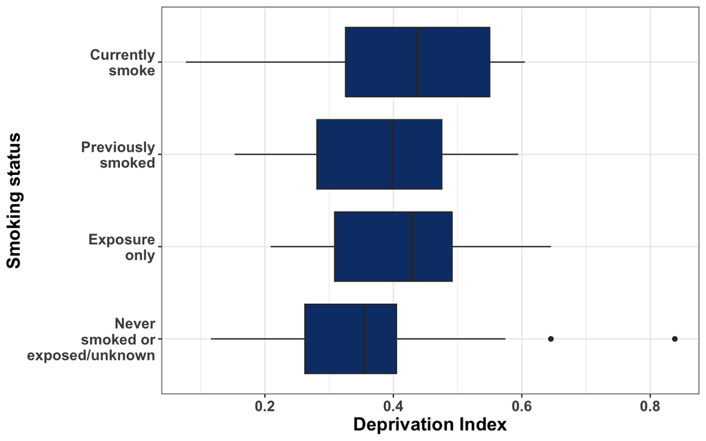

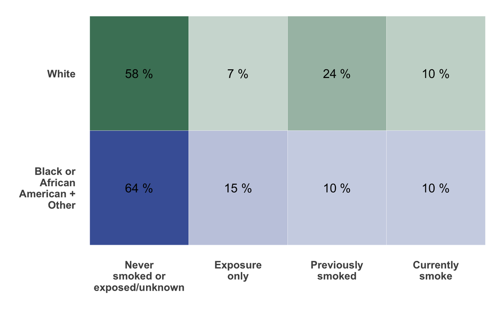

# 3 Baseline Disease Status

## 3.1 Descriptive Summaries

### 3.1.1 Main Summary

| **Characteristic** | **N** | **Overall**, N = 215<sup>1</sup> | **White**, N = 148<sup>1</sup> | **Black or African American**, N = 59<sup>1</sup> | **Other/Unknown**, N = 8<sup>1</sup> |
| --- | --- | --- | --- | --- | --- |
| Degree of asthma severity | 215 |  |  |  |  |
| moderate |  | 106 (49.3%) | 75 (50.7%) | 27 (45.8%) | 4 (50.0%) |
| severe |  | 109 (50.7%) | 73 (49.3%) | 32 (54.2%) | 4 (50.0%) |
| Covid dx within 12 months prior to biologic initiation | 215 |  |  |  |  |
| No |  | 200 (93.0%) | 137 (92.6%) | 55 (93.2%) | 8 (100.0%) |
| Yes |  | 15 (6.98%) | 11 (7.43%) | 4 (6.78%) | 0 (0%) |

<sup>1</sup> n (%)

### 3.1.2 Previously treated with clinic administered medication

| Value | Other/Unknown (N = 8) | Black or African American (N = 59) | White (N = 148) | Total (N = 215) |
| --- | --- | --- | --- | --- |
| None of the above | 6 (75%) | 54 (91.5%) | 127 (85.8%) | 187 (87%) |
| Xolair | 2 (25%) | 3 (5.1%) | 13 (8.8%) | 18 (8.4%) |
| Nucala | 1 (12.5%) | 2 (3.4%) | 5 (3.4%) | 8 (3.7%) |
| Fasenra | 0 (0%) | 1 (1.7%) | 4 (2.7%) | 5 (2.3%) |
| Cinqair | 1 (12.5%) | 0 (0%) | 1 (0.7%) | 2 (0.9%) |

# 4 PDC and Persistence

| **Characteristic** | **N** | **N = 157**<sup>1</sup> |
| --- | --- | --- |
| PDC | 157 |  |
| Mean (SD) |  | 0.90 (0.14) |
| Median (IQR) |  | 0.96 (0.88 - 1.00) |
| Range |  | 0.32 - 1.00 |
| Fills | 157 |  |
| Mean (SD) |  | 10.80 (3.94) |
| Median (IQR) |  | 12.00 (8.00 - 14.00) |
| Range |  | 3.00 - 26.00 |
| Number of switches | 157 |  |
| 0 |  | 148 (94.3%) |
| 1 |  | 8 (5.10%) |
| 3 |  | 1 (0.64%) |
| Gap days | 157 |  |
| Mean (SD) |  | 32.32 (47.17) |
| Median (IQR) |  | 13.00 (1.00 - 35.00) |
| Range |  | 0.00 - 238.00 |
| Gaps >90 days | 157 |  |
| 0 |  | 149 (94.9%) |
| 1 |  | 8 (5.10%) |

<sup>1</sup> n (%)

| **Characteristic** | **N** | **White**, N = 104<sup>1</sup> | **Black or African American + Other**, N = 53<sup>1</sup> | **p-value**<sup>2</sup> |
| --- | --- | --- | --- | --- |
| PDC | 157 |  |  | 0.104 |
| Mean (SD) |  | 0.92 (0.12) | 0.87 (0.17) |  |
| Median (IQR) |  | 0.97 (0.91 - 1.00) | 0.95 (0.74 - 0.99) |  |
| Range |  | 0.43 - 1.00 | 0.32 - 1.00 |  |
| Fills | 157 |  |  | 0.461 |
| Mean (SD) |  | 11.00 (4.01) | 10.42 (3.79) |  |
| Median (IQR) |  | 12.00 (8.75 - 14.00) | 12.00 (8.00 - 14.00) |  |
| Range |  | 3.00 - 26.00 | 3.00 - 15.00 |  |
| Number of switches | 157 |  |  | 0.030 |
| 0 |  | 96 (92.3%) | 52 (98.1%) |  |
| 1 |  | 8 (7.69%) | 0 (0%) |  |
| 3 |  | 0 (0%) | 1 (1.89%) |  |
| Gap days | 157 |  |  | 0.095 |
| Mean (SD) |  | 26.32 (41.28) | 44.11 (55.54) |  |
| Median (IQR) |  | 7.50 (0.75 - 29.50) | 17.00 (2.00 - 85.00) |  |
| Range |  | 0.00 - 202.00 | 0.00 - 238.00 |  |
| Gap days (percent) | 157 |  |  | 0.126 |
| Mean (SD) |  | 8.33 (12.32) | 13.48 (16.80) |  |
| Median (IQR) |  | 2.73 (0.21 - 9.61) | 5.31 (0.55 - 25.66) |  |
| Range |  | 0.00 - 56.74 | 0.00 - 68.00 |  |
| Gaps >90 days | 157 |  |  | 0.718 |
| 0 |  | 98 (94.2%) | 51 (96.2%) |  |
| 1 |  | 6 (5.77%) | 2 (3.77%) |  |

<sup>1</sup> n (%)  
<sup>2</sup> Wilcoxon rank sum test; Fisher’s exact test

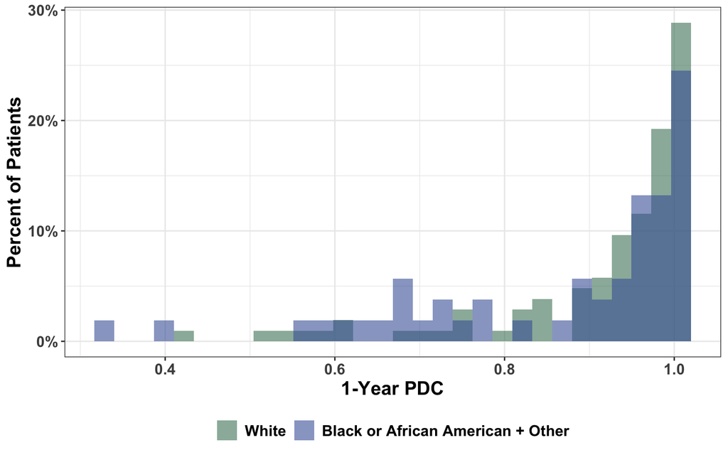

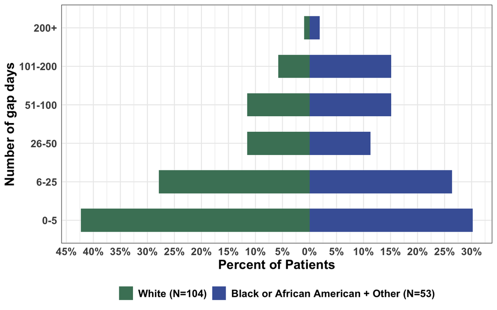

# 5 Follow-up

## 5.1 Descriptive Summary

| **Characteristic** | **N** | **Overall**, N = 185<sup>1</sup> | **White**, N = 126<sup>1</sup> | **Black or African American**, N = 52<sup>1</sup> | **Other/Unknown**, N = 7<sup>1</sup> |
| --- | --- | --- | --- | --- | --- |
| Age | 185 |  |  |  |  |
| Mean (SD) |  | 43 (20) | 47 (20) | 36 (20) | 33 (14) |
| Median (IQR) |  | 46 (24, 58) | 52 (36, 61) | 36 (16, 54) | 40 (20, 44) |
| Range |  | 6, 84 | 6, 84 | 7, 79 | 15, 48 |
| Gender | 185 |  |  |  |  |
| Female |  | 100 (54.1%) | 64 (50.8%) | 30 (57.7%) | 6 (85.7%) |
| Male |  | 85 (45.9%) | 62 (49.2%) | 22 (42.3%) | 1 (14.3%) |
| Race | 185 |  |  |  |  |
| White |  | 126 (68.1%) | 126 (100.0%) | 0 (0%) | 0 (0%) |
| Black or African American |  | 52 (28.1%) | 0 (0%) | 52 (100.0%) | 0 (0%) |
| American Indian or Alaska Native |  | 2 (1.08%) | 0 (0%) | 0 (0%) | 2 (28.6%) |
| Native Hawaiian or Other Pacific Islander |  | 1 (0.54%) | 0 (0%) | 0 (0%) | 1 (14.3%) |
| Middle Eastern |  | 3 (1.62%) | 0 (0%) | 0 (0%) | 3 (42.9%) |
| Race not mentioned |  | 0 (0%) | 0 (0%) | 0 (0%) | 0 (0%) |
| Mixed race |  | 1 (0.54%) | 0 (0%) | 0 (0%) | 1 (14.3%) |
| Insurance type | 185 |  |  |  |  |
| Medicare |  | 38 (20.5%) | 30 (23.8%) | 8 (15.4%) | 0 (0%) |
| Medicaid |  | 30 (16.2%) | 13 (10.3%) | 16 (30.8%) | 1 (14.3%) |
| Tricare |  | 6 (3.24%) | 1 (0.79%) | 4 (7.69%) | 1 (14.3%) |
| Commercial |  | 103 (55.7%) | 75 (59.5%) | 23 (44.2%) | 5 (71.4%) |
| Medicare/Medicaid |  | 1 (0.54%) | 1 (0.79%) | 0 (0%) | 0 (0%) |
| Commercial/Medicaid |  | 4 (2.16%) | 4 (3.17%) | 0 (0%) | 0 (0%) |
| None |  | 2 (1.08%) | 1 (0.79%) | 1 (1.92%) | 0 (0%) |
| Other |  | 1 (0.54%) | 1 (0.79%) | 0 (0%) | 0 (0%) |
| Smoking status | 185 |  |  |  |  |
| Never smoker/Never exposure or Unknown |  | 111 (60.0%) | 72 (57.1%) | 32 (61.5%) | 7 (100.0%) |
| Exposure |  | 17 (9.19%) | 10 (7.94%) | 7 (13.5%) | 0 (0%) |
| Previous |  | 39 (21.1%) | 32 (25.4%) | 7 (13.5%) | 0 (0%) |
| Current |  | 18 (9.73%) | 12 (9.52%) | 6 (11.5%) | 0 (0%) |
| Diagnosis | 185 |  |  |  |  |
| Moderate-persistent asthma |  | 96 (51.9%) | 66 (52.4%) | 25 (48.1%) | 5 (71.4%) |
| Severe-persistent asthma |  | 89 (48.1%) | 60 (47.6%) | 27 (51.9%) | 2 (28.6%) |
| Medication | 185 |  |  |  |  |
| Dupixent |  | 152 (82.2%) | 99 (78.6%) | 47 (90.4%) | 6 (85.7%) |
| Nucala |  | 20 (10.8%) | 17 (13.5%) | 2 (3.85%) | 1 (14.3%) |
| Fasenra |  | 6 (3.24%) | 5 (3.97%) | 1 (1.92%) | 0 (0%) |
| Xolair |  | 7 (3.78%) | 5 (3.97%) | 2 (3.85%) | 0 (0%) |

<sup>1</sup> n (%)

## 5.2 FEV1 Percent Predicted

| **Characteristic** | **N = 43**<sup>1</sup> |
| --- | --- |
| FEV pp at follow-up |  |
| Mean (SD) | 77 (24) |
| Median (IQR) | 78 (64, 94) |
| Range | 21, 128 |
| FEV pp at baseline |  |
| Mean (SD) | 70 (24) |
| Median (IQR) | 74 (57, 85) |
| Range | 21, 118 |
| Race |  |
| White | 26 (60.5%) |
| Black or African American + Other | 17 (39.5%) |
| Smoking |  |
| Never smoker/Never exposure or Unknown | 27 (62.8%) |
| Exposure | 6 (14.0%) |
| Previous | 6 (14.0%) |
| Current | 4 (9.30%) |

<sup>1</sup> n (%)

Table 5.1: Table 5.2: MLR Model Summary for FEV1 Percent Predicted at follow-up

|  | Estimate | P-value |
| --- | --- | --- |
| FEV1 pp at baseline | 0.65 | 0.00 |
| Black or African American + Other | 2.04 | 0.71 |
| **Smoking (Reference: Never smoker/Never exposure or Unknown)** |  |  |
| Exposure | -7.01 | 0.35 |
| Previous | -14.89 | 0.06 |
| Current | -16.50 | 0.09 |

Table 5.3: Table 5.4: Results of bulk tests for factor variables

|  | Degrees of freedom | F statistic | P-value |
| --- | --- | --- | --- |
| Smoking | 3 | 1.94 | 0.14 |

| **Characteristic** | **White**, N = 26 | **Black or African American + Other**, N = 17 | **p-value**<sup>1</sup> |
| --- | --- | --- | --- |
| FEV1 percent predicted at baseline |  |  | 0.2 |
| Mean (SD) | 73 (25) | 65 (24) |  |
| Median (IQR) | 74 (57, 87) | 63 (54, 79) |  |
| Range | 21, 118 | 26, 112 |  |
| FEV1 percent predicted at follow-up |  |  | 0.6 |
| Mean (SD) | 77 (25) | 77 (24) |  |
| Median (IQR) | 82 (70, 93) | 72 (63, 95) |  |
| Range | 21, 123 | 41, 128 |  |
| Absolute change in FEV1 percent predicted from baseline to follow-up |  |  | 0.7 |
| Mean (SD) | 5 (12) | 12 (25) |  |
| Median (IQR) | 3 (-2, 10) | 4 (-1, 20) |  |
| Range | -28, 29 | -26, 65 |  |
| Percent change in FEV1 percent predicted from baseline to follow-up |  |  | 0.6 |
| Mean (SD) | 8 (16) | 32 (66) |  |
| Median (IQR) | 3 (-2, 16) | 6 (-2, 48) |  |
| Range | -26, 40 | -27, 246 |  |

<sup>1</sup> Wilcoxon rank sum exact test

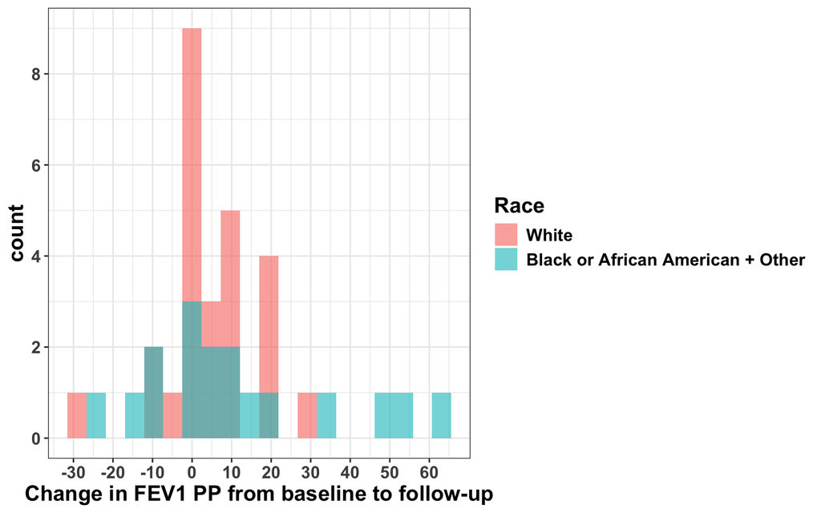

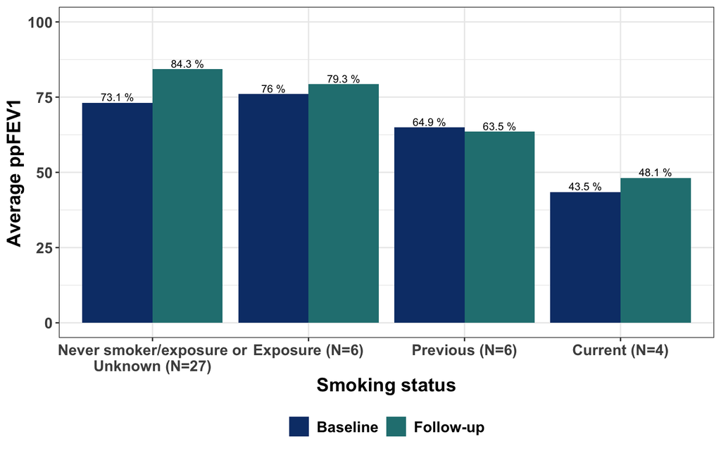

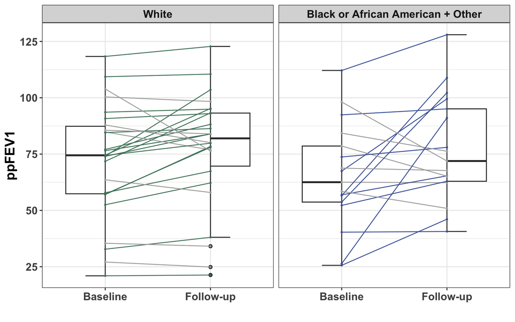

# 6 Implementation Follow Up Analysis

| **Characteristic** | **Gap > 14 days**, N = 52<sup>1</sup> | **No gap > 14 days**, N = 105<sup>1</sup> |
| --- | --- | --- |
| Age at first fill |  |  |
| Mean (SD) | 37 (18) | 44 (21) |
| Median (IQR) | 40 (18, 53) | 48 (23, 60) |
| Range | 7, 67 | 6, 80 |
| Race |  |  |
| White | 29 (55.8%) | 75 (71.4%) |
| Black or African American + Other | 23 (44.2%) | 30 (28.6%) |
| Insurance type |  |  |
| Commercial | 34 (65.4%) | 60 (57.1%) |
| Medicaid | 12 (23.1%) | 17 (16.2%) |
| Medicare | 4 (7.69%) | 22 (21.0%) |
| Tricare/Other/None | 2 (3.85%) | 6 (5.71%) |

<sup>1</sup> n (%)